# Pika Stress

# Habitat Factors at each site

This data set is also from “Physiological stress of American pika (Ochotona princeps) and associated habitat characteristics for Niwot Ridge, 2018 - 2019” by Whipple and Ray. This one in particular is looking at the differences in different types of cover in each of the sites, which affects how much territory pikas can have, and therefore theoretically how stressed they may be. As seen in this diagram, every site has a high average percentage cover of rocks, with the Cable Gate site having the most. The West Knoll site has the most average percentage of forbs and grass cover, and it has no shrub or tree coverage. I chose to facet the graphs by site to compare the average percent coverage of each type of cover across the sites. I colored the bars by the cover type to further distinguish them and make them look visually appealing. Lastly, I changed the angle of the x-axis labels because they were crowded otherwise.

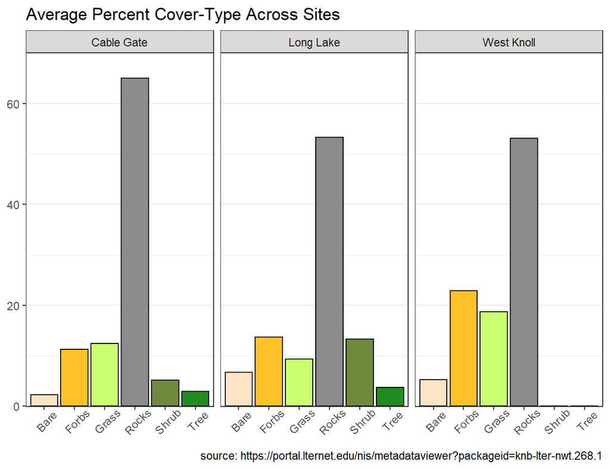

```r
ggplot(data=hf, mapping=aes(x=Cover_Type, y=Mean_Perc_Cover)) +
  geom_bar(stat="identity", aes(fill=Cover_Type), color="black") +
  facet_wrap(vars(Site), labeller=labeller(Site=site_labs)) +
  scale_fill_manual(values=c("Bisque", "goldenrod1", "darkolivegreen1","gray55", "darkolivegreen4", "forestgreen")) +
  scale_x_discrete(name="Cover Type") +
  scale_y_continuous(name="Mean Percent Cover", expand=expansion(0,0.05), limits=c(0,70)) +
    labs(title="Average Percent Cover-Type Across Sites", caption="source: https://portal.lternet.edu/nis/metadataviewer?packageid=knb-lter-nwt.268.1") +
  theme_bw() +
  theme(axis.text.x=element_text(angle=45, vjust=.8), panel.grid.major.x=element_blank(), panel.grid.minor.x=element_blank(), legend.position="none", axis.title=element_blank())
```